# One small step for image recognition, one giant leap for mankind: handwritten digits recognition

DSB EA - Group 3

Project team: DATTAWADKAR Anay anay.dattawadkar@insead.edu; GUO Tingting tingting.guo@insead.edu; MELMAN Ilia ilia.melman@insead.edu; WEI Anais anais.wei@insead.edu; WIRAWAN Christian christian.wirawan@insead.edu; ZHAN Chris chris.zhan@insead.edu

Image recognition is a rapidly-evolving AI technology with numerous current and future use cases. From facial recognition to autonomous driving, image processing is an essential step for a machine to understand the world we are living.

The project is our exploratory step towards image recognition usage through simple data science models. We wish to get a glimpse through the eyes of the machine, understand the process to tackle the problem, and discuss the potentials and challenges through hands-on classification models.

Handwritten digits data is based on the known MNIST dataset: http://yann.lecun.com/exdb/mnist/

# 1. Business applications of image recognition

Image recognition has extensive usage across various industries. Its current application includes facial recognition, image search, object recognition, pattern detection, biometrics identification, augmented reality, and many more scenarios.

As a result, image recognition can be applied across a broad range of industries including manufacturing, autonomous driving, medial, banking, etc ...

**Digit recognition**

OCR (Optical Character Recognition) is one of the simplest but most powerful usages of image recognition. It has been used to automate manual processes that are currently not digitalized.

Documents, invoices, bank cheques, and envelopes can be converted into a machine-readable format, which becomes an important step in process automation for companies.

With this exercise, our objective is to adopt the data modeling process to classify digit images into the correct numbers for efficient processing in the OCR application. The project serves as our first step in exploring image recognition applications, which can be further extended into alphabet conversion, pattern recognition, and advanced object detection.

# 2. How does the machine see an image?

## 2.1 Turn image into data steam

Computer screens represent images by splitting each pixel into a combination of 3 different colors. Red, Green, and Blue can be mixed to create almost any color in the spectrum. Computers can “read” images by converting their component pixels into arrays of red, green, and blue values. These pixels are then further split into 3-D arrays of code; models can then apply machine learning techniques to “recognize” and “classify” these images.

## 2.2 The dataset

We use the known MNIST dataset to train and test our models: MNIST dataset contains 1. 60,000 handwritten digits training dataset 2. 10,000 handwritten digits test dataset

The training dataset(csv) is a matrix of [60000, 785] numeric values. The test dataset(csv) is a matrix of [10000, 785] numeric values.

Each row within the dataset represents one image of a handwritten digit of 28 * 28 pixels (784):

*X1 = Y: the value of the single-digit, from 0 to 9*

*X2 - X785: values representing the brightness of each pixel, from 0 (Black) to 255 (White)*

Let’s try to load the first 100 training data!

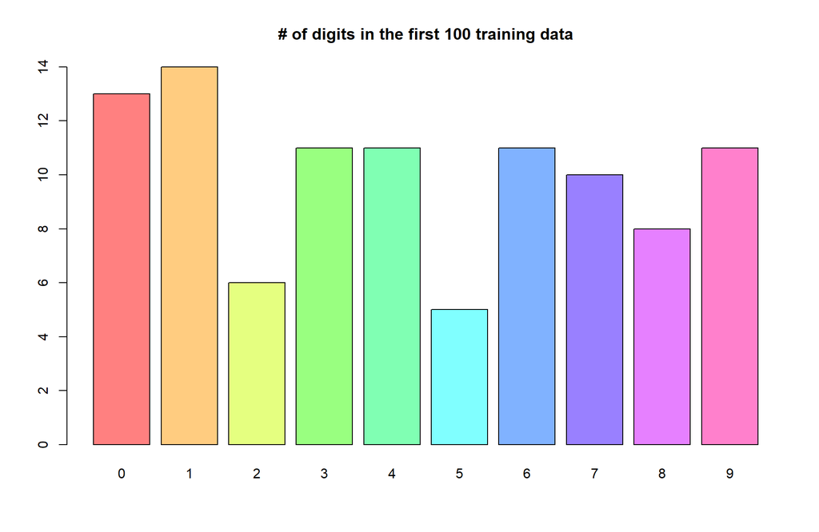

The first image looks like this in pixels:

| 0 | 0 | 0 | 0 | 0 | 0 | 0 | 0 | 0 | 0 | 0 | 0 | 0 | 0 | 0 | 0 | 0 | 0 | 0 | 0 | 0 | 0 | 0 | 0 | 0 | 0 | 0 | 0 |
| --- | --- | --- | --- | --- | --- | --- | --- | --- | --- | --- | --- | --- | --- | --- | --- | --- | --- | --- | --- | --- | --- | --- | --- | --- | --- | --- | --- |
| 0 | 0 | 0 | 0 | 0 | 0 | 0 | 0 | 0 | 0 | 0 | 0 | 0 | 0 | 0 | 0 | 0 | 0 | 0 | 0 | 0 | 0 | 0 | 0 | 0 | 0 | 0 | 0 |
| 0 | 0 | 0 | 0 | 0 | 0 | 0 | 0 | 0 | 0 | 0 | 0 | 0 | 0 | 0 | 0 | 0 | 0 | 0 | 0 | 0 | 0 | 0 | 0 | 0 | 0 | 0 | 0 |
| 0 | 0 | 0 | 0 | 0 | 0 | 0 | 0 | 0 | 0 | 0 | 0 | 0 | 0 | 0 | 0 | 0 | 0 | 0 | 0 | 0 | 0 | 0 | 0 | 0 | 0 | 0 | 0 |
| 0 | 0 | 0 | 0 | 0 | 0 | 0 | 0 | 0 | 0 | 0 | 0 | 0 | 0 | 0 | 0 | 0 | 0 | 0 | 0 | 0 | 0 | 0 | 0 | 0 | 0 | 0 | 0 |
| 0 | 0 | 0 | 0 | 0 | 0 | 0 | 0 | 0 | 0 | 0 | 0 | 3 | 18 | 18 | 18 | 126 | 136 | 175 | 26 | 166 | 255 | 247 | 127 | 0 | 0 | 0 | 0 |
| 0 | 0 | 0 | 0 | 0 | 0 | 0 | 0 | 30 | 36 | 94 | 154 | 170 | 253 | 253 | 253 | 253 | 253 | 225 | 172 | 253 | 242 | 195 | 64 | 0 | 0 | 0 | 0 |
| 0 | 0 | 0 | 0 | 0 | 0 | 0 | 49 | 238 | 253 | 253 | 253 | 253 | 253 | 253 | 253 | 253 | 251 | 93 | 82 | 82 | 56 | 39 | 0 | 0 | 0 | 0 | 0 |
| 0 | 0 | 0 | 0 | 0 | 0 | 0 | 18 | 219 | 253 | 253 | 253 | 253 | 253 | 198 | 182 | 247 | 241 | 0 | 0 | 0 | 0 | 0 | 0 | 0 | 0 | 0 | 0 |
| 0 | 0 | 0 | 0 | 0 | 0 | 0 | 0 | 80 | 156 | 107 | 253 | 253 | 205 | 11 | 0 | 43 | 154 | 0 | 0 | 0 | 0 | 0 | 0 | 0 | 0 | 0 | 0 |
| 0 | 0 | 0 | 0 | 0 | 0 | 0 | 0 | 0 | 14 | 1 | 154 | 253 | 90 | 0 | 0 | 0 | 0 | 0 | 0 | 0 | 0 | 0 | 0 | 0 | 0 | 0 | 0 |
| 0 | 0 | 0 | 0 | 0 | 0 | 0 | 0 | 0 | 0 | 0 | 139 | 253 | 190 | 2 | 0 | 0 | 0 | 0 | 0 | 0 | 0 | 0 | 0 | 0 | 0 | 0 | 0 |
| 0 | 0 | 0 | 0 | 0 | 0 | 0 | 0 | 0 | 0 | 0 | 11 | 190 | 253 | 70 | 0 | 0 | 0 | 0 | 0 | 0 | 0 | 0 | 0 | 0 | 0 | 0 | 0 |
| 0 | 0 | 0 | 0 | 0 | 0 | 0 | 0 | 0 | 0 | 0 | 0 | 35 | 241 | 225 | 160 | 108 | 1 | 0 | 0 | 0 | 0 | 0 | 0 | 0 | 0 | 0 | 0 |
| 0 | 0 | 0 | 0 | 0 | 0 | 0 | 0 | 0 | 0 | 0 | 0 | 0 | 81 | 240 | 253 | 253 | 119 | 25 | 0 | 0 | 0 | 0 | 0 | 0 | 0 | 0 | 0 |
| 0 | 0 | 0 | 0 | 0 | 0 | 0 | 0 | 0 | 0 | 0 | 0 | 0 | 0 | 45 | 186 | 253 | 253 | 150 | 27 | 0 | 0 | 0 | 0 | 0 | 0 | 0 | 0 |
| 0 | 0 | 0 | 0 | 0 | 0 | 0 | 0 | 0 | 0 | 0 | 0 | 0 | 0 | 0 | 16 | 93 | 252 | 253 | 187 | 0 | 0 | 0 | 0 | 0 | 0 | 0 | 0 |
| 0 | 0 | 0 | 0 | 0 | 0 | 0 | 0 | 0 | 0 | 0 | 0 | 0 | 0 | 0 | 0 | 0 | 249 | 253 | 249 | 64 | 0 | 0 | 0 | 0 | 0 | 0 | 0 |
| 0 | 0 | 0 | 0 | 0 | 0 | 0 | 0 | 0 | 0 | 0 | 0 | 0 | 0 | 46 | 130 | 183 | 253 | 253 | 207 | 2 | 0 | 0 | 0 | 0 | 0 | 0 | 0 |
| 0 | 0 | 0 | 0 | 0 | 0 | 0 | 0 | 0 | 0 | 0 | 0 | 39 | 148 | 229 | 253 | 253 | 253 | 250 | 182 | 0 | 0 | 0 | 0 | 0 | 0 | 0 | 0 |
| 0 | 0 | 0 | 0 | 0 | 0 | 0 | 0 | 0 | 0 | 24 | 114 | 221 | 253 | 253 | 253 | 253 | 201 | 78 | 0 | 0 | 0 | 0 | 0 | 0 | 0 | 0 | 0 |
| 0 | 0 | 0 | 0 | 0 | 0 | 0 | 0 | 23 | 66 | 213 | 253 | 253 | 253 | 253 | 198 | 81 | 2 | 0 | 0 | 0 | 0 | 0 | 0 | 0 | 0 | 0 | 0 |
| 0 | 0 | 0 | 0 | 0 | 0 | 18 | 171 | 219 | 253 | 253 | 253 | 253 | 195 | 80 | 9 | 0 | 0 | 0 | 0 | 0 | 0 | 0 | 0 | 0 | 0 | 0 | 0 |
| 0 | 0 | 0 | 0 | 55 | 172 | 226 | 253 | 253 | 253 | 253 | 244 | 133 | 11 | 0 | 0 | 0 | 0 | 0 | 0 | 0 | 0 | 0 | 0 | 0 | 0 | 0 | 0 |
| 0 | 0 | 0 | 0 | 136 | 253 | 253 | 253 | 212 | 135 | 132 | 16 | 0 | 0 | 0 | 0 | 0 | 0 | 0 | 0 | 0 | 0 | 0 | 0 | 0 | 0 | 0 | 0 |
| 0 | 0 | 0 | 0 | 0 | 0 | 0 | 0 | 0 | 0 | 0 | 0 | 0 | 0 | 0 | 0 | 0 | 0 | 0 | 0 | 0 | 0 | 0 | 0 | 0 | 0 | 0 | 0 |
| 0 | 0 | 0 | 0 | 0 | 0 | 0 | 0 | 0 | 0 | 0 | 0 | 0 | 0 | 0 | 0 | 0 | 0 | 0 | 0 | 0 | 0 | 0 | 0 | 0 | 0 | 0 | 0 |
| 0 | 0 | 0 | 0 | 0 | 0 | 0 | 0 | 0 | 0 | 0 | 0 | 0 | 0 | 0 | 0 | 0 | 0 | 0 | 0 | 0 | 0 | 0 | 0 | 0 | 0 | 0 | 0 |

Display the first 36 images visually.

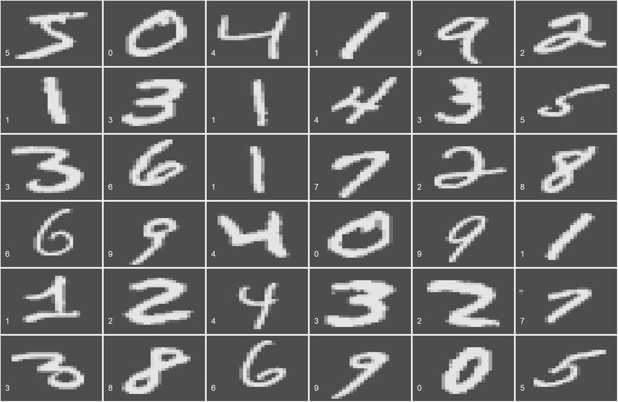

# 3. Classification models

After exploring the data structure and visualization, we decide to apply a few simple models to train the machine to read the digits.

> * multiclass logistic classification * Random Forest * XGboost * neural networks

## 3.1 Multi-nominal logistics

Firstly, we train on 30,000 single digit images with multi-nominal logistics model.

Training performance:

```r
#TEMP: accuracy on training data
train_data_sample_r <- train_data
train_data_sample_r$pred <-predict(logistic_model,train_data_sample_r, type = "class")
confmat_train <- table ('Actual Class (training)' = train_data_sample_r$Label, 'Predicted Class (training)' = train_data_sample_r$pred)
confmat_train
```

```
##                        Predicted Class (training)
## Actual Class (training)    0    1    2    3    4    5    6    7    8    9
##                       0 2931    0    1    3    1    6    8    0    8    3
##                       1    1 3375   11    2    1    8    2    3   18    2
##                       2    8   12 2776   30   19    8   11   14   59   11
##                       3    9    9   44 2872    2   69    3   11   38   16
##                       4    2    6   16    5 2806    1   12    3   13   62
##                       5   10    3   13   53   17 2540   16    2   43   12
##                       6    7    5    7    1    5   25 2917    0    7    1
##                       7    1    5   21    7   16    2    0 2993    5   57
##                       8    6   29   29   51    8   51   13    7 2658   23
##                       9    3    7    7   26   46   15    1   50   22 2826
```

```r
accuracy_train <- sum(diag(confmat_train))/sum(confmat_train)
cat ("Accuracy achieved on the training data set is: ", accuracy_train*100, "%\n")
```

```
## Accuracy achieved on the training data set is:  95.64667 %
```

```
## Let's see some error examples: handwritten 3 which are predicted as 5.
```

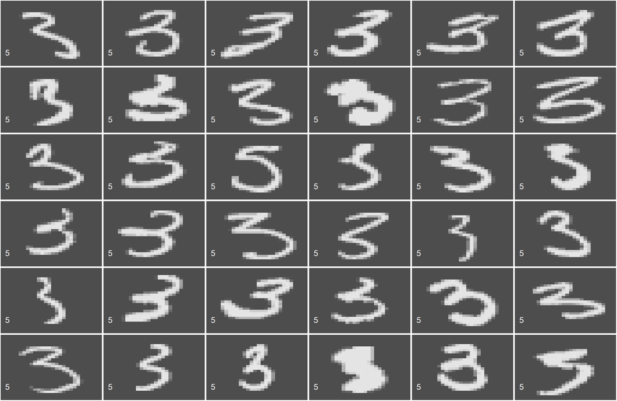

*** Then, we use the model to recognize digits from the 10,000 testing datasets:

```
##             Predicted Class
## Actual Class    0    1    2    3    4    5    6    7    8    9
##            0  934    0    6    4    0   15   12    6    3    0
##            1    0 1109    6    4    1    1    4    1    8    1
##            2    6   13  921   19    9   10    9   13   28    4
##            3    4    4   23  898    2   32    2   15   20   10
##            4    3    3    9    5  896    2   14    8   10   32
##            5   12    3    5   37    6  758   19    5   41    6
##            6   12    7   18    2    6   23  883    3    2    2
##            7    2   12   17    9    9    1    1  937    5   35
##            8    9    9   11   22    8   29   14   14  847   11
##            9    6    8    1   10   29    6    3   29   14  903
```

```
## Accuracy achieved on the test data set is:  90.86 %
```

```
## Let's see some error examples within the test results: handwritten 4 which are predicted as 9.
```

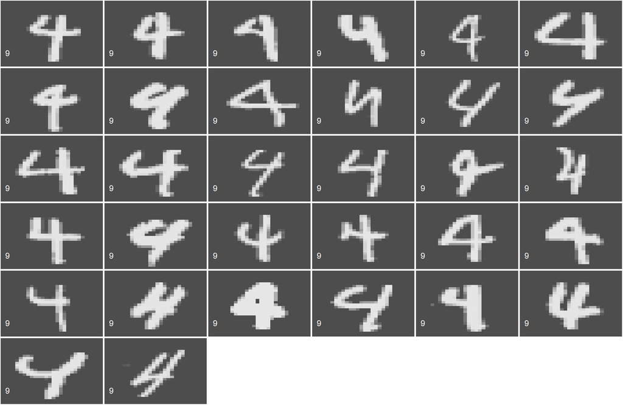

## 3.2 Random Forest

The second model we used is a randome forest. We train with initially 80% of 60,000 single digit images.

```r
set.seed(4)
rf.model <- randomForest(label ~ ., data = digit, ntree = 100, nodesize = 50)
rf.predict <- predict(rf.model, digit_test)

print(rf.cm <- confusionMatrix(rf.predict, digit_test$label))
```

```
## Confusion Matrix and Statistics
##
##           Reference
## Prediction    0    1    2    3    4    5    6    7    8    9
##          0  969    0    7    2    1    6    8    1    4    8
##          1    0 1117    0    0    0    0    3    2    0    4
##          2    0    3  980   15    2    2    1   27    6    2
##          3    0    4   10  959    0   14    0    2    7   15
##          4    0    1    7    2  942    4    3    1    4   16
##          5    2    1    0    7    1  842    6    0    9    2
##          6    3    4    7    0    7    9  932    0    6    1
##          7    1    1    9    9    0    3    0  973    4    4
##          8    5    4   11   13    6    8    5    6  921   12
##          9    0    0    1    3   23    4    0   16   13  945
##
## Overall Statistics
##
##                Accuracy : 0.958
##                  95% CI : (0.9539, 0.9618)
##     No Information Rate : 0.1135
##     P-Value [Acc > NIR] : < 2.2e-16
##
##                   Kappa : 0.9533
##
##  Mcnemar's Test P-Value : NA
##
## Statistics by Class:
##
##                      Class: 0 Class: 1 Class: 2 Class: 3 Class: 4 Class: 5
## Sensitivity            0.9888   0.9841   0.9496   0.9495   0.9593   0.9439
## Specificity            0.9959   0.9990   0.9935   0.9942   0.9958   0.9969
## Pos Pred Value         0.9632   0.9920   0.9441   0.9486   0.9612   0.9678
## Neg Pred Value         0.9988   0.9980   0.9942   0.9943   0.9956   0.9945
## Prevalence             0.0980   0.1135   0.1032   0.1010   0.0982   0.0892
## Detection Rate         0.0969   0.1117   0.0980   0.0959   0.0942   0.0842
## Detection Prevalence   0.1006   0.1126   0.1038   0.1011   0.0980   0.0870
## Balanced Accuracy      0.9923   0.9916   0.9716   0.9719   0.9775   0.9704
##                      Class: 6 Class: 7 Class: 8 Class: 9
## Sensitivity            0.9729   0.9465   0.9456   0.9366
## Specificity            0.9959   0.9965   0.9922   0.9933
## Pos Pred Value         0.9618   0.9691   0.9294   0.9403
## Neg Pred Value         0.9971   0.9939   0.9941   0.9929
## Prevalence             0.0958   0.1028   0.0974   0.1009
## Detection Rate         0.0932   0.0973   0.0921   0.0945
## Detection Prevalence   0.0969   0.1004   0.0991   0.1005
## Balanced Accuracy      0.9844   0.9715   0.9689   0.9649
```

```r
print(paste("Accuracy of Random Forest:", round(rf.cm$overall[1], 4)))
```

```
## [1] "Accuracy of Random Forest: 0.958"
```

## 3.3 XGBoost

The third model we used is XGBoost. We attempted to also use cross-validation on the dataset to check if accuracy can be improved with the metrics of merror.

```
## Confusion Matrix and Statistics
##
##           Reference
## Prediction    1    2    3    4    5    6    7    8    9   10
##         1  1115    0    2    1    3    3    5    7    6    0
##         2     2  959   16    2    2    0   28    9    5    0
##         3     2   15  936    0   23    0    3    7    6    0
##         4     0   10    1  919    3    9    3    8   19    0
##         5     0    0    7    0  819   14    1    9    6    0
##         6     5    5    4    8   10  909    0    5    1    0
##         7     1   15   15    2    6    0  959    5    7    0
##         8     8   13   17   10   12   15    5  902    7    0
##         9     1    4   10   39    6    0   23   15  944    0
##         10    0    0    0    0    0    0    0    0    0    0
##
## Overall Statistics
##
##                Accuracy : 0.9431
##                  95% CI : (0.9381, 0.9478)
##     No Information Rate : 0.1264
##     P-Value [Acc > NIR] : < 2.2e-16
##
##                   Kappa : 0.9359
##
##  Mcnemar's Test P-Value : NA
##
## Statistics by Class:
##
##                      Class: 1 Class: 2 Class: 3 Class: 4 Class: 5 Class: 6
## Sensitivity            0.9832   0.9393   0.9286   0.9368  0.92647   0.9568
## Specificity            0.9966   0.9920   0.9930   0.9934  0.99543   0.9953
## Pos Pred Value         0.9764   0.9374   0.9435   0.9455  0.95678   0.9599
## Neg Pred Value         0.9976   0.9922   0.9910   0.9923  0.99199   0.9949
## Prevalence             0.1264   0.1138   0.1123   0.1093  0.09852   0.1059
## Detection Rate         0.1243   0.1069   0.1043   0.1024  0.09127   0.1013
## Detection Prevalence   0.1273   0.1140   0.1106   0.1083  0.09540   0.1055
## Balanced Accuracy      0.9899   0.9656   0.9608   0.9651  0.96095   0.9761
##                      Class: 7 Class: 8 Class: 9 Class: 10
## Sensitivity            0.9338   0.9328   0.9431        NA
## Specificity            0.9936   0.9891   0.9877         1
## Pos Pred Value         0.9495   0.9120   0.9060        NA
## Neg Pred Value         0.9915   0.9919   0.9928        NA
## Prevalence             0.1145   0.1078   0.1116         0
## Detection Rate         0.1069   0.1005   0.1052         0
## Detection Prevalence   0.1126   0.1102   0.1161         0
## Balanced Accuracy      0.9637   0.9610   0.9654        NA
```

```
## [1] "Accuracy of XGBoost is: 0.9431"
```

## 3.4 Neural Networks

The last attempt is neral network with tensor flow and keras library. With the 30 Epoch, below is the diagram of loss and accuracy through the training.

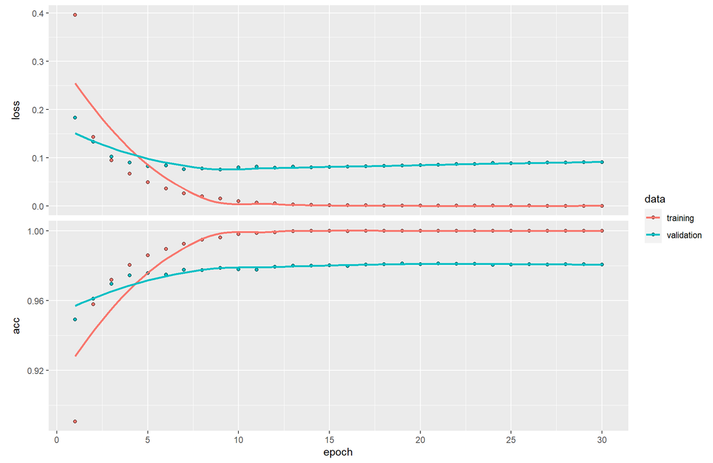

```
## $loss
## [1] 0.08026497
##
## $acc
## [1] 0.9815
```

```
##          Actual
## Predicted    0    1    2    3    4    5    6    7    8    9
##         0  969    0    5    1    2    2    4    1    3    2
##         1    1 1128    1    0    0    0    2    5    0    2
##         2    1    3 1007    0    2    0    1    6    2    0
##         3    0    0    2  995    1    9    1    3    5    5
##         4    1    0    2    0  963    1    4    0    4    8
##         5    1    1    0    3    0  870    4    0    1    2
##         6    3    2    2    0    3    4  941    0    2    1
##         7    1    0    7    3    1    1    1 1008    2    4
##         8    3    1    5    4    1    3    0    2  949    0
##         9    0    0    1    4    9    2    0    3    6  985
```

## 3.5 Compare results

After fine-tuning the parameters, the models yield the following accuracy levels with the following parameters:

[output not shown]

# 4. Challenges of image recognition

Despite great advances, today’s image recognition models still face significant limitations, and there is a long way to go.

## 4.1 Computers lack “common sense”

Computers do not know when to say "I don't know". As such, even when presented with spurious data, the algorithm will attempt to make a prediction based on its training. This “overconfidence” can have inaccurate/comical results

## 4.2 Difficulties with model generalization

Models are trained and evaluated by randomly splitting data into “training” and “testing”. Real-world data can differ in viewing angles, scene configurations, camera quality, and other factors. When applied to circumstances beyond their training, models become increasingly inaccurate.

## 4.3 Potential malicious attacks

People have been able to “fool” image recognition models by using carefully-constructed “noise”. So-called “adversarial attacks” are model-agnostic, enabling easy “transferability” across a range of algorithms and use cases. This raises significant security concerns.

## 4.4 Comprehensive scene understanding

Algorithms today can identify objects and groups within a scene (perception). However, they struggle to understand object relationships (what is happening). As such, they cannot yet form a cognitive understanding of the physical world.